# Исследование данных опросов при помощи Excel и Python

# Содержание

## Описание проекта

Всероссийская организация родителей детей-инвалидов (ВОРДИ) проводит мониторинг, где проводит исследование оценки родителями социальной политики по нормализации жизни и социальной инклюзии детей-инвалидов и детей с особыми потребностями Белгородской области.

Если опираться на встречу-презентацию результатов мониторинга [2022 года](https://index2022.as-dr.ru/) и посмотреть полностью [видео встречи](https://www.youtube.com/watch?v=SxzN9HDFTrw&t=2s), то можно выделить такие **Основные задачи**:

- выявить наиболее проблемные общие места: кому, по каким направлениям, каким категориям наиболее необходима помощь
- помочь организации принимать эффективные управленческие решения на основе данных, снизить "долю ручного управления"
- объяснить и обосновать логику работы с данными, вывести и обосновать метрики, придерживаясь объективного и научного подхода
- выявить принципы успешной цифровой обработки опросов, чтобы можно было применить и расширить этот опыт для других социально-незащищённых категорий граждан (дети-сироты, малоимущие и т.д.)

**План работы**:

- работа с предоставленными данными в Excel/Goggle-Таблицах: категоризация вопросов, обработка ответов, подсчёт по категориям, составление таблиц с агрегированными данными
- открытие созданных таблиц в jupyter notebook
- создание и объяснение метрик
- анализ и визуализация
- выводы

**Описание данных**:

- заказчиком исследования были предоставлены сырые данные опросов за 2021 и 2022 год (файлы excel, данные в виде текста)

Основная работа была произведена в Excel/Google-Таблицах. Возможно, этот инструмент более доступен родителям-участникам организации, и кто-то из команды Ворди сможет в дальнейшем использовать что-то из моей работы в Excel.

## Открытие данных

Импортируем библиотеки:

```python
import pandas as pd
import os
from matplotlib import pyplot as plt
import seaborn as sns
import textwrap
```

```python
import warnings
warnings.filterwarnings("ignore")
pd.set_option('display.max_columns', None)
```

Открываем файлы:

```python
if os.path.exists('/datasets/vordi_project/questions_21.xlsx'):
    questions_21 = pd.read_excel('/datasets/vordi_project/questions_21.xlsx')
else:
    questions_21 = pd.read_excel('/C:/datasets/vordi_project/questions_21.xlsx')
```

```python
if os.path.exists('/datasets/vordi_project/questions_22.xlsx'):
    questions_22 = pd.read_excel('/datasets/vordi_project/questions_22.xlsx')
else:
    questions_22 = pd.read_excel('/C:/datasets/vordi_project/questions_22.xlsx')
```

```python
if os.path.exists('/datasets/vordi_project/sum_21.xlsx'):
    sum_21 = pd.read_excel('/datasets/vordi_project/sum_21.xlsx')
else:
    sum_21 = pd.read_excel('/C:/datasets/vordi_project/sum_21.xlsx')
```

```python
if os.path.exists('/datasets/vordi_project/sum_22.xlsx'):
    sum_22 = pd.read_excel('/datasets/vordi_project/sum_22.xlsx')
else:
    sum_22 = pd.read_excel('/C:/datasets/vordi_project/sum_22.xlsx')
```

```python
if os.path.exists('/datasets/vordi_project/people_21.xlsx'):
    people_21 = pd.read_excel('/datasets/vordi_project/people_21.xlsx')
else:
    people_21 = pd.read_excel('/C:/datasets/vordi_project/people_21.xlsx')
```

```python
if os.path.exists('/datasets/vordi_project/people_22.xlsx'):
    people_22 = pd.read_excel('/datasets/vordi_project/people_22.xlsx')
else:
    people_22 = pd.read_excel('/C:/datasets/vordi_project/people_22.xlsx')
```

```python
if os.path.exists('/datasets/vordi_project/text_21.xlsx'):
    text_21 = pd.read_excel('/datasets/vordi_project/text_21.xlsx')
else:
    text_21 = pd.read_excel('/C:/datasets/vordi_project/text_21.xlsx')
```

```python
if os.path.exists('/datasets/vordi_project/text_22.xlsx'):
    text_22 = pd.read_excel('/datasets/vordi_project/text_22.xlsx')
else:
    text_22 = pd.read_excel('/C:/datasets/vordi_project/text_22.xlsx')
```

Эти файлы - отдельные листы из книг Excel, где была проведена работа с данными.

Работа происходила следующим образом: из каждого файла опроса (их два, за 2021 и 2022 г.) была сделана книга Excel с несколькими листами. Перечислю листы книг с их содержанием:

1: Export - "сырые" данные опросов

2: questions - здесь собрана вся информация о самих вопросах:

- порядковый номер вопроса (чтобы у всех вопросов был свой номер)
- номер категории (для объединения вопросов в группы по смыслу, взят из сырых данных)
- описание категории (небольшое описание каждой группы)
- номер вопроса внутри категории (взят из сырых данных)
- описание вопроса (типовые фразы, которые дублируются в разных группах)
- количество уникальных ответов (для того чтобы выявить вопросы, где нет типовых ответов)
- технический статус ("стандарт" - переводится в баллы-цифры, "варианты" и "комментарии" перевести в баллы-цифры невозможно/нежелательно)
- к какому элементу из 10 элементов среды относится вопрос (так рассчитывают рейтинг качества жизни в [АСИ](https://asi.ru/government_officials/quality-of-life-ranking/#howitworks))
- текст вопроса

3: answers - здесь собрана информация об ответах:

- для каждого вопроса указан текст, порядковый номер, количество уникальных ответов, технический тип
- выведены варианты ответов
- и указано, на какие баллы-цифры ответы "стандарт" будут заменены

4: Result - здесь собраны все вопросы типа "стандарт", и ответы на них, переведённые в баллы-цифры. Общая логика: 1 - да/удовлетворён, 0.5 - скорее да/удовлетворён частично, 0 - затрудняюсь ответить, -0.5 - скорее нет/скорее не удовлетворён, -1 - нет/не удовлетворён.

- здесь есть расчёты суммы баллов и количество ответов по каждому вопросу
- есть подсчёт суммы баллов по каждой строке (т.е. для каждого опрошенного отдельно)
- и здесь есть расчёты данных по категориям вопросов, по 10 элементам среды и по ключевым описаниям вопросов

5: sum_21 и sum_22 - сумма баллов для каждого вопроса типа "стандарт"

6: table_1 - здесь те данные обо всех вопросах, которые пригодятся для исследования

7: table_2 - сгруппированные данные подсчётов по категориям, элементам среды и ключевым описаниям вопросов

8: people - для каждого опрошенного (id):

- общая сумма баллов (total) при ответе на все вопросы
- сумма баллов по каждой категории
- сумма баллов по каждому из 10 элементов среды
- сумма баллов по каждому ключевому описанию вопросов

9: text - здесь собраны все вопросы типов "варианты" и "комментарии" и весь блок личной информации для каждого опрошенного

Работа с данными в Excel проводилась при помощи встроенных формул и функций (иногда удобнее пользоваться Google-Таблицами, например, это там удобнее реализована формула =UNIQUE и функция "Найти и заменить"). Чтобы быстрее ориентироваться в большом объёме данных, на некоторых листах добавлена заливка цветом ключевых столбцов или строк (например, на листе Result).

Теперь ключевые листы из книг Excel мы откроем здесь, в Jupyter Notebook.

```python
df_questions_21 = questions_21.merge(sum_21, on='question_text', how='left')
df_questions_22 = questions_22.merge(sum_22, on='question_text', how='left')
```

```python
df_questions_21.head()
```

|  | number | category_number | category_description | question_number | question_description | unique_answers_cnt | tech_status | 10_elements_of_environment | question_text | sum_21 | perc_satisfaction_21 |
| --- | --- | --- | --- | --- | --- | --- | --- | --- | --- | --- | --- |
| 0 | 1 | 1 | общие вопросы | 1.0 | инклюзия | 5.0 | стандарт | инклюзивность | 1.1. Можно ли сказать, что в нашем регионе соз... | 111.0 | 11.133400 |
| 1 | 2 | 1 | общие вопросы | 2.0 | возможности | 4.0 | стандарт | инклюзивность | 1.2. Можно ли сказать, что ваш ребенок имеет т... | 228.0 | 22.868606 |
| 2 | 3 | 1 | общие вопросы | 3.1 | социальные права и свободы | 3.0 | стандарт | возможности для работы и своего дела | 1.3. Как Вы считаете, соблюдаются ли в полной ... | 280.0 | 28.084253 |
| 3 | 4 | 1 | общие вопросы | 3.2 | социальные права и свободы | 3.0 | стандарт | потребление и досуг | 1.3. Как Вы считаете, соблюдаются ли в полной ... | 417.0 | 41.825476 |
| 4 | 5 | 1 | общие вопросы | 3.3 | социальные права и свободы | 3.0 | стандарт | социальная защита | 1.3. Как Вы считаете, соблюдаются ли в полной ... | 488.0 | 48.946841 |

```python
df_questions_22.head()
```

|  | number | category_number | category_description | question_number | question_description | unique_answers_cnt_22 | tech_status | 10_elements_of_environment | question_text | sum_22 | perc_satisfaction_22 |
| --- | --- | --- | --- | --- | --- | --- | --- | --- | --- | --- | --- |
| 0 | 1 | 1 | общие вопросы | 1.0 | инклюзия | 4.0 | стандарт | инклюзивность | 1.1. Можно ли сказать, что в нашем регионе соз... | 210.0 | 18.901890 |
| 1 | 2 | 1 | общие вопросы | 2.0 | возможности | 4.0 | стандарт | инклюзивность | 1.2. Можно ли сказать, что ваш ребенок имеет т... | 321.0 | 28.892889 |
| 2 | 3 | 1 | общие вопросы | 3.1 | социальные права и свободы | 3.0 | стандарт | возможности для работы и своего дела | 1.3. Как Вы считаете, соблюдаются ли в полной ... | 522.0 | 46.984698 |
| 3 | 4 | 1 | общие вопросы | 3.2 | социальные права и свободы | 3.0 | стандарт | потребление и досуг | 1.3. Как Вы считаете, соблюдаются ли в полной ... | 597.0 | 53.735374 |
| 4 | 5 | 1 | общие вопросы | 3.3 | социальные права и свободы | 3.0 | стандарт | социальная защита | 1.3. Как Вы считаете, соблюдаются ли в полной ... | 719.0 | 64.716472 |

## Сравнение различных категорий с помощью метрики "процент удовлетворения"

У нас есть ответы, оцифрованные в такой общей логике:

- 1 - положительный ответ
- 0.5 - скорее положительный
- 0 - затруднения в ответе/нейтрально/прочее
- -0.5 - скорее отрицательный
- -1 - отрицательный

Мы вычислили их сумму по каждому вопросу. То есть если бы у всех участников был положительный ответ (1), то сумма баллов была бы равна количеству участников. Например, 997 участников - и возможный максимум 997 баллов.

И возможно наоборот - если у всех участников проблемы в каком-то вопросе (-1), то максимально возможный минимум -997 баллов.

Скорее всего, в каждом вопросе мы будем видеть смешанную картину, но общая сумма может говорить о **преобладании** проблем или удовлетворения по каждому вопросу. Чем выше сумма - тем больше удовлетворения, чем меньше сумма - тем больше проблем.

Но чтобы понимать этот показатель **в контексте** (в разные годы количество участников разное), мы определим, какой процент составляет сумма баллов от количества участников. Так мы получим более объективный показатель - назовём его **% общей удовлетворённости**.

С его помощью мы сможем выявить вопросы и категории вопросов, где участники в большинстве своём испытывают проблемы.

Выделим в отдельный датафрейм те строки, где у нас есть оцифрованные данные и соответственно есть расчёты метрики "процент удовлетворения". Некоторые вопросы из блока о личных данных тоже имеют тип стандарт, но они нам сейчас не нужны, поэтому задаём два условия, чтобы отобрать нужные данные:

```python
df_21 = df_questions_21.query('tech_status == "стандарт" and perc_satisfaction_21 < 101')
df_22 = df_questions_22.query('tech_status == "стандарт" and perc_satisfaction_22 < 101')
df_21
```

|  | number | category_number | category_description | question_number | question_description | unique_answers_cnt | tech_status | 10_elements_of_environment | question_text | sum_21 | perc_satisfaction_21 |
| --- | --- | --- | --- | --- | --- | --- | --- | --- | --- | --- | --- |
| 0 | 1 | 1 | общие вопросы | 1.00 | инклюзия | 5.0 | стандарт | инклюзивность | 1.1. Можно ли сказать, что в нашем регионе соз... | 111.0 | 11.133400 |
| 1 | 2 | 1 | общие вопросы | 2.00 | возможности | 4.0 | стандарт | инклюзивность | 1.2. Можно ли сказать, что ваш ребенок имеет т... | 228.0 | 22.868606 |
| 2 | 3 | 1 | общие вопросы | 3.10 | социальные права и свободы | 3.0 | стандарт | возможности для работы и своего дела | 1.3. Как Вы считаете, соблюдаются ли в полной ... | 280.0 | 28.084253 |
| 3 | 4 | 1 | общие вопросы | 3.20 | социальные права и свободы | 3.0 | стандарт | потребление и досуг | 1.3. Как Вы считаете, соблюдаются ли в полной ... | 417.0 | 41.825476 |
| 4 | 5 | 1 | общие вопросы | 3.30 | социальные права и свободы | 3.0 | стандарт | социальная защита | 1.3. Как Вы считаете, соблюдаются ли в полной ... | 488.0 | 48.946841 |
| ... | ... | ... | ... | ... | ... | ... | ... | ... | ... | ... | ... |
| 336 | 337 | 18 | обществ.организации | 5.12 | варианты | 4.0 | стандарт | медицинское обслуживание | [Реабилитационные занятия] | 62.0 | 6.218656 |
| 337 | 338 | 18 | обществ.организации | 5.13 | варианты | 4.0 | стандарт | потребление и досуг | [Адаптивный спорт] | 53.0 | 5.315948 |
| 340 | 341 | 18 | обществ.организации | 8.00 | ВОРДИ | 3.0 | стандарт | социальная защита | 18.8. Знаете ли Вы о работе регионального отде... | -560.0 | -56.168506 |
| 341 | 342 | 18 | обществ.организации | 9.00 | ВОРДИ | 3.0 | стандарт | социальная защита | 18.9. Знаете ли Вы о проекте Семейная онлайн-п... | -593.0 | -59.478435 |
| 342 | 343 | 18 | обществ.организации | 10.00 | инициатива | 3.0 | стандарт | социальная защита | 18.10. Как Вы считаете, должны ли родители объ... | 500.0 | 50.150451 |

307 rows × 11 columns

### Категории вопросов

Создадим датафрейм, сгруппировав данные по категориям вопросов:

```python
df_category_21 = (df_21.groupby('category_description', as_index=False)
                   .agg({'perc_satisfaction_21':'mean'}))
df_category_22 = (df_22.groupby('category_description', as_index=False)
                   .agg({'perc_satisfaction_22':'mean'}))
df_category = df_category_22.merge(df_category_21, on='category_description', how='left')
df_category['dynamic'] = df_category['perc_satisfaction_22'] - df_category['perc_satisfaction_21']
df_category = df_category.sort_values(by='perc_satisfaction_22', ascending=False)
```

Рассчитаем среднее:

```python
mean_2021 = df_category['perc_satisfaction_21'].mean()
mean_2022 = df_category['perc_satisfaction_22'].mean()
mean_dynamic = df_category['dynamic'].mean()
```

Построим график для наглядности:

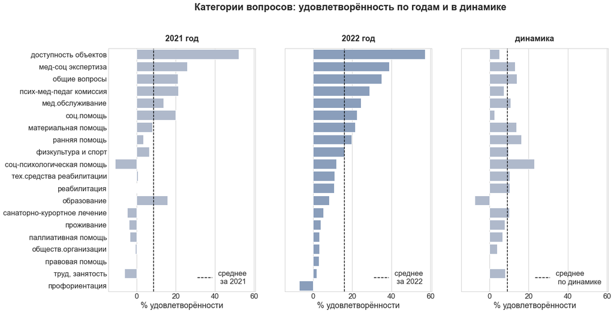

```python
plt.figure(figsize=(20, 10))
sns.set(font_scale=1.5)
plt.style.use('seaborn-whitegrid')
plt.suptitle('Категории вопросов: удовлетворённость по годам и в динамике',
             fontweight='bold', y=1.02)

ax1=plt.subplot(1, 3, 1)
sns.barplot(data=df_category, y='category_description', x='perc_satisfaction_21', color='#aab8d0')
plt.axvline(x=mean_2021, color='black', linestyle='--', label='среднее \n за 2021')
plt.legend(loc='lower right')
plt.title('2021 год', fontweight='bold', y=1.02)
plt.xlabel('% удовлетворённости')
plt.ylabel('')

ax2=plt.subplot(1, 3, 2, sharex=ax1)
sns.barplot(data=df_category, y='category_description', x='perc_satisfaction_22', color='#829cc3')
plt.axvline(x=mean_2022, color='black', linestyle='--', label='среднее \n за 2022')
plt.legend(loc='lower right')
plt.title('2022 год', fontweight='bold', y=1.02)
plt.xlabel('% удовлетворённости')
plt.ylabel('')
ax2.set(yticklabels=[])
ax2.tick_params(left=False)

ax3=plt.subplot(1, 3, 3, sharex=ax1)
sns.barplot(data=df_category, y='category_description', x='dynamic', color='#aab8d0')
plt.axvline(x=mean_dynamic, color='black', linestyle='--', label='среднее \n по динамике')
plt.legend(loc='lower right')
plt.title('динамика', fontweight='bold', y=1.02)
plt.xlabel('% удовлетворённости')
plt.ylabel('')
ax3.set(yticklabels=[])
ax3.tick_params(left=False)

plt.show();
```

### 10 элементов окружающей среды

Создаём датафрейм:

```python
df_environment_21 = (df_21.groupby('10_elements_of_environment', as_index=False)
                   .agg({'perc_satisfaction_21':'mean', 'question_number':'count'})
                   .rename(columns={'question_number':'question_cnt_21'}))
df_environment_22 = (df_22.groupby('10_elements_of_environment', as_index=False)
                   .agg({'perc_satisfaction_22':'mean', 'question_number':'count'})
                   .rename(columns={'question_number':'question_cnt_22'}))
df_environment = df_environment_22.merge(df_environment_21, on='10_elements_of_environment', how='left')
df_environment['dynamic'] = df_environment['perc_satisfaction_22'] - df_environment['perc_satisfaction_21']
df_environment = df_environment.sort_values(by='perc_satisfaction_22', ascending=False)
```

Снова рассчитаем среднее:

```python
mean_2021 = df_environment['perc_satisfaction_21'].mean()
mean_2022 = df_environment['perc_satisfaction_22'].mean()
mean_dynamic = df_environment['dynamic'].mean()
```

И построим график:

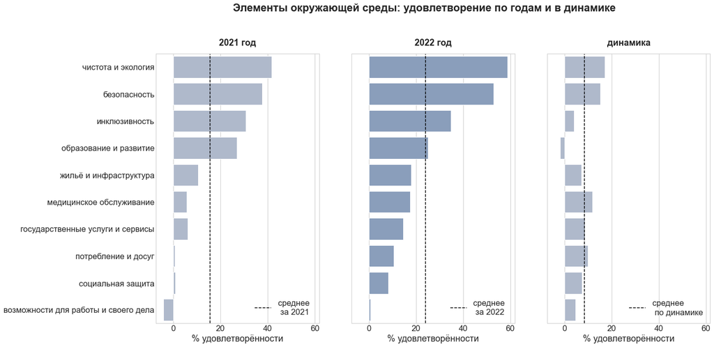

```python
plt.figure(figsize=(20, 10))
sns.set(font_scale=1.5)
plt.style.use('seaborn-whitegrid')
plt.suptitle('Элементы окружающей среды: удовлетворение по годам и в динамике',
             fontweight='bold', y=1.02)

ax1=plt.subplot(1, 3, 1)
sns.barplot(data=df_environment, y='10_elements_of_environment', x='perc_satisfaction_21', color='#aab8d0')
plt.axvline(x=mean_2021, color='black', linestyle='--', label='среднее \n за 2021')
plt.legend(loc='lower right')
plt.title('2021 год', fontweight='bold', y=1.02)
plt.xlabel('% удовлетворённости')
plt.ylabel('')

ax2=plt.subplot(1, 3, 2, sharex=ax1)
sns.barplot(data=df_environment, y='10_elements_of_environment', x='perc_satisfaction_22', color='#829cc3')
plt.axvline(x=mean_2022, color='black', linestyle='--', label='среднее \n за 2022')
plt.legend(loc='lower right')
plt.title('2022 год', fontweight='bold', y=1.02)
plt.xlabel('% удовлетворённости')
plt.ylabel('')
ax2.set(yticklabels=[])
ax2.tick_params(left=False)

ax3=plt.subplot(1, 3, 3, sharex=ax1)
sns.barplot(data=df_environment, y='10_elements_of_environment', x='dynamic', color='#aab8d0')
plt.axvline(x=mean_dynamic, color='black', linestyle='--', label='среднее \n по динамике')
plt.legend(loc='lower right')
plt.title('динамика', fontweight='bold', y=1.02)
plt.xlabel('% удовлетворённости')
plt.ylabel('')
ax3.set(yticklabels=[])
ax3.tick_params(left=False)

plt.show();
```

- на обоих графиках (и за 2021, и за 2022 год) мы видим, что сильно выделяются в положительную сторону разделы "чистота и экология" и "безопасность". Но здесь надо учитывать, что в этих категориях всего по одному вопросу, и они носят общий характер (из категории 1 - общие вопросы). Ниже можно прочитать формулировку этих вопросов
- инклюзивность и образование/развитие родители оценивают выше среднего
- возможности для работы и своего дела - самая слабая категория в оба года
- другие сферы: социальная защита, потребление и досуг, госуд.услуги и сервисы, мед.обслуживание, жильё и инфраструктура "выросли" по сравнению с опросом 2021 года, но находятся на уровне не более 20% удовлетворённости
- единственная категория показывает небольшую отрицательную динамику - образование и развитие

```python
pd.set_option('display.max_colwidth', None)
```

```python
df_21.loc[df_21['10_elements_of_environment'] == "безопасность"]['question_text']
```

```
5    1.3. Как Вы считаете, соблюдаются ли в полной мере социальные права и свободы настоящего и будущего для вашего ребенка? [Право на охрану и помощь семье]
Name: question_text, dtype: object
```

```python
df_21.loc[df_21['10_elements_of_environment'] == "чистота и экология"]['question_text']
```

```
8    1.3. Как Вы считаете, соблюдаются ли в полной мере социальные права и свободы настоящего и будущего для вашего ребенка? [Право на благоприятную окружающую среду]
Name: question_text, dtype: object
```

### Ключевое описание вопросов

```python
df_question_descr_21 = (df_21.groupby('question_description', as_index=False)
                   .agg({'perc_satisfaction_21':'mean'}))
df_question_descr_22 = (df_22.groupby('question_description', as_index=False)
                   .agg({'perc_satisfaction_22':'mean'}))
df_question_descr = df_question_descr_22.merge(df_question_descr_21, on='question_description', how='left')
df_question_descr['dynamic'] = df_question_descr['perc_satisfaction_22'] - df_question_descr['perc_satisfaction_21']
df_question_descr = df_question_descr.sort_values(by='perc_satisfaction_22', ascending=False)
```

```python
mean_2021 = df_question_descr['perc_satisfaction_21'].mean()
mean_2022 = df_question_descr['perc_satisfaction_22'].mean()
mean_dynamic = df_question_descr['dynamic'].mean()
```

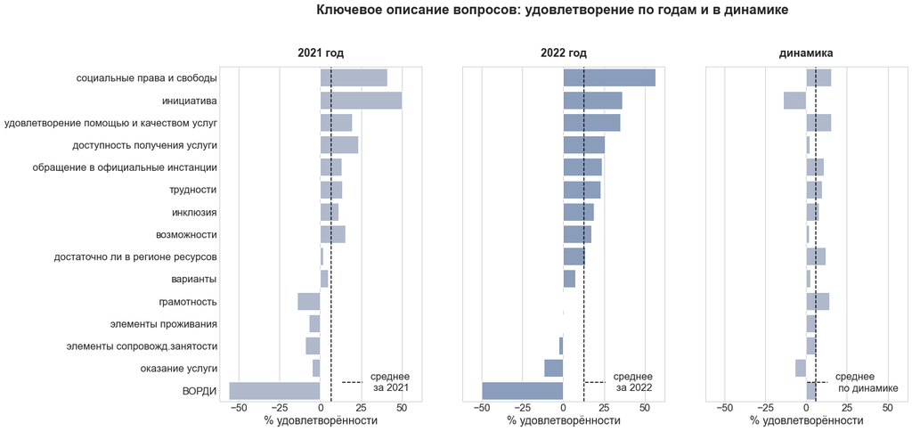

```python
plt.figure(figsize=(20, 10))
sns.set(font_scale=1.5)
plt.style.use('seaborn-whitegrid')
plt.suptitle('Ключевое описание вопросов: удовлетворение по годам и в динамике',
             fontweight='bold', y=1.02)

ax1=plt.subplot(1, 3, 1)
sns.barplot(data=df_question_descr, y='question_description', x='perc_satisfaction_21', color='#aab8d0')
plt.axvline(x=mean_2021, color='black', linestyle='--', label='среднее \n за 2021')
plt.legend(loc='lower right')
plt.title('2021 год', fontweight='bold', y=1.02)
plt.xlabel('% удовлетворённости')
plt.ylabel('')

ax2=plt.subplot(1, 3, 2, sharex=ax1)
sns.barplot(data=df_question_descr, y='question_description', x='perc_satisfaction_22', color='#829cc3')
plt.axvline(x=mean_2022, color='black', linestyle='--', label='среднее \n за 2022')
plt.legend(loc='lower right')
plt.title('2022 год', fontweight='bold', y=1.02)
plt.xlabel('% удовлетворённости')
plt.ylabel('')
ax2.set(yticklabels=[])
ax2.tick_params(left=False)

ax3=plt.subplot(1, 3, 3, sharex=ax1)
sns.barplot(data=df_question_descr, y='question_description', x='dynamic', color='#aab8d0')
plt.axvline(x=mean_dynamic, color='black', linestyle='--', label='среднее \n по динамике')
plt.legend(loc='lower right')
plt.title('динамика', fontweight='bold', y=1.02)
plt.xlabel('% удовлетворённости')
plt.ylabel('')
ax3.set(yticklabels=[])
ax3.tick_params(left=False)

plt.show();
```

- лучше всего родители оценивают социальные права и свободы (это 1-я категория общих вопросов) - больше половины ответов в 2022 году - положительные
- несмотря на высокие показатели, инициативность родителей имеет отрицательную динамику
- категория вопросов про Ворди сильно отличается: родители очень часто отвечают отрицательно - около половины опрошенных не знают о работе организации (формулировка вопросов ниже)
- в 2022 году количество "отрицательных" категорий сократилось, теперь это только 3 направления (вместо 5 в 2021 году): Ворди, оказание услуги и элементы сопровождаемой занятости.
- оказание услуги - эта категория имеет стабильно низкие показатели - в оба года отрицательный результат и отрицательная динамика. Значит, многие родители отвечают "нет" на вопросы "получаете ли вы ... услугу?"

```python
df_22.loc[df_22['question_description'] == "ВОРДИ"]['question_text'].to_list()
```

```
['20.8. Знаете ли Вы о работе регионального отделения ВОРДИ (Всероссийская организация родителей детей-инвалидов) в Белгородской области?',
 '20.9. Знаете ли Вы о проекте Семейная приемная ВОРДИ?']
```

## Вопросы

Посмотрим на вопросы, которые собрали наибольшее количество отрациательных ответов:

```python
df_questions_21.sort_values(by='perc_satisfaction_21').head(10)
```

|  | number | category_number | category_description | question_number | question_description | unique_answers_cnt | tech_status | 10_elements_of_environment | question_text | sum_21 | perc_satisfaction_21 |
| --- | --- | --- | --- | --- | --- | --- | --- | --- | --- | --- | --- |
| 272 | 273 | 15 | паллиативная помощь | 1.0 | оказание услуги | 4.0 | стандарт | медицинское обслуживание | 15.1. Получает ли ваш ребенок паллиативную помощь? | -746.0 | -74.824473 |
| 313 | 314 | 18 | обществ.организации | 1.0 | оказание услуги | 4.0 | стандарт | социальная защита | 18.1. Пользовались ли Вы услугами благотворительных общественных организаций? | -594.0 | -59.578736 |
| 341 | 342 | 18 | обществ.организации | 9.0 | ВОРДИ | 3.0 | стандарт | социальная защита | 18.9. Знаете ли Вы о проекте Семейная онлайн-приемная (https://lk.as-dr.ru/)? | -593.0 | -59.478435 |
| 340 | 341 | 18 | обществ.организации | 8.0 | ВОРДИ | 3.0 | стандарт | социальная защита | 18.8. Знаете ли Вы о работе регионального отделения ВОРДИ (Всероссийская организация родителей детей-инвалидов) в Белгородской области? | -560.0 | -56.168506 |
| 135 | 136 | 7 | санаторно-курортное лечение | 1.0 | оказание услуги | 4.0 | стандарт | потребление и досуг | 7.1. Получаете ли ваш ребенок санаторно-курортное лечение? | -524.0 | -52.557673 |
| 122 | 123 | 6 | тех.средства реабилитации | 1.0 | оказание услуги | 4.0 | стандарт | медицинское обслуживание | 6.1. Нуждается ли ваш ребенок в получении технических средств реабилитации и получаете ли Вы их в полной мере? | -485.0 | -48.645938 |
| 232 | 233 | 13 | соц-психологическая помощь | 1.0 | оказание услуги | 4.0 | стандарт | социальная защита | 13.1. Получаете ли Вы социально-психологическую и правовую помощь? | -348.0 | -34.904714 |
| 299 | 300 | 17 | доступность объектов | 2.0 | оказание услуги | 4.0 | стандарт | инклюзивность | 17.2. Пользуетесь ли Вы услугами социального такси? | -329.0 | -32.998997 |
| 247 | 248 | 13 | соц-психологическая помощь | 6.7 | грамотность | 3.0 | стандарт | потребление и досуг | 13.6. Оцените Вашу правовую и информационную грамотность по вопросам обеспечения поддержки и соблюдения прав детей-инвалидов [Санаторно-курортное лечение для ребенка-инвалида] | -280.0 | -28.084253 |
| 191 | 192 | 10 | реабилитация | 1.0 | оказание услуги | 4.0 | стандарт | медицинское обслуживание | 10.1. Получаете ли ваш ребенок услуги реабилитации? | -275.0 | -27.582748 |

```python
df_questions_22.sort_values(by='perc_satisfaction_22').head(10)
```

|  | number | category_number | category_description | question_number | question_description | unique_answers_cnt_22 | tech_status | 10_elements_of_environment | question_text | sum_22 | perc_satisfaction_22 |
| --- | --- | --- | --- | --- | --- | --- | --- | --- | --- | --- | --- |
| 84 | 85 | 4 | образование | 1.4 | оказание услуги | 4.0 | стандарт | образование и развитие | 4.1. Посещает ли (или посещал в свое время) ваш ребенок учреждения образования? [Учреждение высшего образования] | -750.0 | -67.506751 |
| 306 | 307 | 17 | паллиативная помощь | 1.0 | оказание услуги | 4.0 | стандарт | медицинское обслуживание | 17.1. Получает ли ваш ребенок паллиативную помощь? | -736.0 | -66.246625 |
| 83 | 84 | 4 | образование | 1.3 | оказание услуги | 4.0 | стандарт | образование и развитие | 4.1. Посещает ли (или посещал в свое время) ваш ребенок учреждения образования? [Учреждение среднего профессионального образования] | -685.0 | -61.656166 |
| 347 | 348 | 20 | обществ.организации | 1.0 | оказание услуги | 4.0 | стандарт | социальная защита | 20.1. Пользовались ли Вы услугами благотворительных общественных организаций? | -629.0 | -56.615662 |
| 375 | 376 | 20 | обществ.организации | 9.0 | ВОРДИ | 3.0 | стандарт | социальная защита | 20.9. Знаете ли Вы о проекте Семейная приемная ВОРДИ? | -583.0 | -52.475248 |
| 254 | 255 | 14 | правовая помощь | 1.0 | оказание услуги | 4.0 | стандарт | государственные услуги и сервисы | 14.1. Получаете ли Вы правовую помощь? | -572.0 | -51.485149 |
| 280 | 281 | 15 | профориентация | 1.0 | оказание услуги | 4.0 | стандарт | возможности для работы и своего дела | 15.1. Проводится ли с Вашим ребенком профориентация? | -571.0 | -51.395140 |
| 374 | 375 | 20 | обществ.организации | 8.0 | ВОРДИ | 3.0 | стандарт | социальная защита | 20.8. Знаете ли Вы о работе регионального отделения ВОРДИ (Всероссийская организация родителей детей-инвалидов) в Белгородской области? | -528.0 | -47.524752 |
| 148 | 149 | 7 | санаторно-курортное лечение | 1.0 | оказание услуги | 4.0 | стандарт | потребление и досуг | 7.1. Получаете ли ваш ребенок санаторно-курортное лечение? | -493.0 | -44.374437 |
| 135 | 136 | 6 | тех.средства реабилитации | 1.0 | оказание услуги | 4.0 | стандарт | медицинское обслуживание | 6.1. Нуждается ли ваш ребенок в получении технических средств реабилитации и получаете ли Вы их в полной мере? | -435.0 | -39.153915 |

```python
df_questions_21.sort_values(by='perc_satisfaction_21').head(10)['question_text'].to_list()
```

```
['15.1. Получает ли ваш ребенок паллиативную помощь?',
 '18.1. Пользовались ли Вы услугами благотворительных общественных организаций?',
 '18.9. Знаете ли Вы о проекте Семейная онлайн-приемная (https://lk.as-dr.ru/)?',
 '18.8. Знаете ли Вы о работе регионального отделения ВОРДИ (Всероссийская организация родителей детей-инвалидов) в Белгородской области?',
 '7.1. Получаете ли ваш ребенок санаторно-курортное лечение?',
 '6.1. Нуждается ли ваш ребенок в получении технических средств реабилитации и получаете ли Вы их в полной мере?',
 '13.1. Получаете ли Вы социально-психологическую и правовую помощь?',
 '17.2. Пользуетесь ли Вы услугами социального такси?',
 '13.6. Оцените Вашу правовую и информационную грамотность по вопросам обеспечения поддержки и соблюдения прав детей-инвалидов [Санаторно-курортное лечение для ребенка-инвалида]',
 '10.1. Получаете ли ваш ребенок услуги реабилитации?']
```

```python
df_questions_22.sort_values(by='perc_satisfaction_22').head(10)['question_text'].to_list()
```

```
['4.1. Посещает ли (или посещал в свое время) ваш ребенок учреждения образования? [Учреждение высшего образования]',
 '17.1. Получает ли ваш ребенок паллиативную помощь?',
 '4.1. Посещает ли (или посещал в свое время) ваш ребенок учреждения образования? [Учреждение среднего профессионального образования]',
 '20.1. Пользовались ли Вы услугами благотворительных общественных организаций?',
 '20.9. Знаете ли Вы о проекте Семейная приемная ВОРДИ?',
 '14.1. Получаете ли Вы правовую помощь?',
 '15.1. Проводится ли с Вашим ребенком профориентация?',
 '20.8. Знаете ли Вы о работе регионального отделения ВОРДИ (Всероссийская организация родителей детей-инвалидов) в Белгородской области?',
 '7.1. Получаете ли ваш ребенок санаторно-курортное лечение?',
 '6.1. Нуждается ли ваш ребенок в получении технических средств реабилитации и получаете ли Вы их в полной мере?']
```

**Вопросы, на которые наиболее часто родители дают отрицательные ответы**, связаны со следующими сферами:

- оказание паллиативной помощи
- получение услуг благотворительных организаций
- проекты и работа Ворди
- получение санаторно-курортного лечения
- получение технических средств реабилитации
- социально-психологическая и правовая помощь
- использование услуг социального такси
- правовая и информационная грамотность
- получение услуги реабилитации
- посещение ребенком учреждений высшего и среднего профессионального образования
- прохождение ребенком профориентации

## Родители и дети

Добавим к исследованию данные о семьях. Кроме этого, поделим родителей на две большие категории: на тех, у кого сумма баллов положительная, и на тех, у кого отрицательная или равна нулю:

```python
text_21.rename(columns={'текст вопроса':'id'}, inplace=True)
text_22.rename(columns={'текст вопроса':'id'}, inplace=True)
```

```python
table_21 = people_21.merge(text_21, on='id', how='left')
table_22 = people_22.merge(text_22, on='id', how='left')
```

```python
def set_status(total):
    if total > 0:
        return 'positive'
    else:
        return 'negative'
```

```python
table_21['status'] = table_21['total'].apply(set_status)
table_22['status'] = table_22['total'].apply(set_status)
```

### Социальный портрет

Попробуем выделить несколько основных вопросов и выделить их в отдельный "социальный портрет":

```python
social_portreit_21 = table_21[['19.1. Укажите, пожалуйста, возраст ребенка-инвалида.',
           '19.6. Опишите, пожалуйста, ваш состав семьи [Полная семья (мать, отец)]',
           'Нозология',
           '19.19. Описывая размер семейного дохода, можно сказать',
           '19.20. Как бы Вы сами определили уровень жизни семьи',
           '19.21. Сколько примерно, в процентном соотношении от дохода семьи, уходит на обслуживание ребенка-инвалида%',
           '19.11. Укажите, пожалуйста, территорию своего проживания:',
           '19.7. Где Вы проживаете?',
           'total', 'status']]
```

```python
social_portreit_22 = table_22[['21.1. Укажите, пожалуйста, возраст ребенка-инвалида.',
           '21.6. Опишите, пожалуйста, ваш состав семьи [Полная семья (мать, отец)]',
           'Нозология',
           '21.19. Описывая размер семейного дохода, можно сказать',
           '21.20. Как бы Вы сами определили уровень жизни семьи',
           '21.21. Сколько примерно, в процентном соотношении от дохода семьи, уходит на обслуживание ребенка-инвалида%',
           '21.11. Укажите, пожалуйста, территорию своего проживания:',
           '21.7. Где Вы проживаете?',
           'total', 'status']]
```

```python
social_portreit_21.columns=['child_age', 'is_family_full', 'type_disease', 'amount_income',
                               'financial_level', 'perc_costs_child', 'district', 'type_place', 'total', 'status']
social_portreit_22.columns=['child_age', 'is_family_full', 'type_disease', 'amount_income',
                               'financial_level', 'perc_costs_child', 'district', 'type_place', 'total', 'status']

social_portreit_21['year'] = 2021
social_portreit_22['year'] = 2022
social_portreit = pd.concat([social_portreit_21, social_portreit_22], ignore_index=True)
social_portreit.head()
```

|  | child_age | is_family_full | type_disease | amount_income | financial_level | perc_costs_child | district | type_place | total | status | year |
| --- | --- | --- | --- | --- | --- | --- | --- | --- | --- | --- | --- |
| 0 | 7-10 лет | -1 | комплексные множественные заболевания | Семье с трудом хватает средств на необходимые траты, связанные с питанием, одеждой, оплатой счетов и лечения | Низкий | Более 75% | Белгород | В городе, региональном центре | -118 | negative | 2021 |
| 1 | 4-6 лет | 1 | врожденные пороки развития | Семье хватает средств на необходимые траты, связанные с питанием, одеждой, оплатой счетов и лечения | Низкий | Более 75% | Белгород | В городе, районном центр | -7 | negative | 2021 |
| 2 | 16-18 лет | 1 | заболевания органов опорно-двигательного аппарата в том числе ДЦП | Семье с трудом хватает средств на необходимые траты, связанные с питанием, одеждой, оплатой счетов и лечения | Низкий | До 50% | Валуйский район | В селе | 22 | positive | 2021 |
| 3 | 11-15 лет | -1 | заболевания органов дыхательной системы | Семье хватает средств на необходимые траты, но на большие покупки и отдых приходится копить (брать кредит) | Средний | До 10% | Новооскольский район | В городе, районном центр | 35 | positive | 2021 |
| 4 | 11-15 лет | 1 | комплексные множественные заболевания | Семье хватает средств не только на необходимые траты, но и на большие покупки, комфортный отдых | Высокий | До 25% | Ракитянский район | В поселке городского типа | 120 | positive | 2021 |

Теперь мы сможем сравнить ответы родителей с положительными и отрицательными суммами баллов и, может быть, найти отличия в каких-то категориях.

## Сравнение ответов родителей с положительными и отрицательными суммами баллов

### Возраст ребёнка

```python
social_portreit_neg = (social_portreit.query('status == "negative"')
                                       .groupby('child_age', as_index=False)
                                       .agg({'status':'count'})
                                       .rename(columns={'status':'status_neg'}))
social_portreit_pos = (social_portreit.query('status == "positive"')
                                       .groupby('child_age', as_index=False)
                                       .agg({'status':'count'})
                                       .rename(columns={'status':'status_pos'}))
type_child_age = social_portreit_neg.merge(social_portreit_pos, on='child_age', how='outer')
type_child_age = type_child_age.sort_values(by='status_neg', ascending=False)
type_child_age['cnt_total'] = type_child_age['status_neg'] + type_child_age['status_pos']
type_child_age['perc'] = type_child_age['status_neg'] / type_child_age['cnt_total'] *100
type_child_age = type_child_age.sort_values(by='status_neg', ascending=False)
type_child_age['child_age'] = type_child_age['child_age'].astype(str)
```

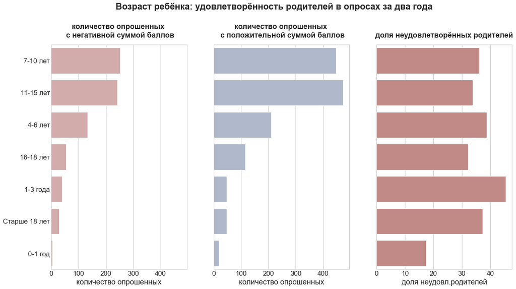

```python
plt.figure(figsize=(20, 10))
sns.set(font_scale=1.5)
plt.style.use('seaborn-whitegrid')
plt.suptitle('Возраст ребёнка: удовлетворённость родителей в опросах за два года',
             fontweight='bold', y=1.02)

ax1=plt.subplot(1, 3, 1)
sns.barplot(data=type_child_age, y='child_age', x='status_neg', color='#d9a6a4')
plt.title('количество опрошенных \n с негативной суммой баллов', fontweight='bold', y=1.02)
plt.xlabel('количество опрошенных')
plt.ylabel('')

ax2=plt.subplot(1, 3, 2, sharex=ax1)
sns.barplot(data=type_child_age, y='child_age', x='status_pos', color='#aab8d0')
plt.title('количество опрошенных \n с положительной суммой баллов', fontweight='bold', y=1.02)
plt.xlabel('количество опрошенных')
plt.ylabel('')
ax2.set(yticklabels=[])
ax2.tick_params(left=False)

ax3=plt.subplot(1, 3, 3)
sns.barplot(data=type_child_age, y='child_age', x='perc', color='#ca817e')
plt.title('доля неудовлетворённых родителей', fontweight='bold', y=1.02)
plt.xlabel('доля неудовл.родителей')
plt.ylabel('')
ax3.set(yticklabels=[])
ax3.tick_params(left=False)

plt.show();
```

- большинство опрошенных - родители детей 7-10 и 11-15 лет, их больше всего и среди удовлетворённых, и среди неудовлетворённых родителей
- наибольшая доля неудовлетворённых - это родители детей в возрасте 1-3 (около 45%) и 4-6 лет (39%)

### Состав семьи (полная или нет)

```python
social_portreit['is_family_full'] = social_portreit['is_family_full'].map({1:'Полная семья', -1:'Нет отца'})
```

```python
social_portreit_neg = (social_portreit.query('status == "negative"')
                                       .groupby('is_family_full', as_index=False)
                                       .agg({'status':'count'})
                                       .rename(columns={'status':'status_neg'}))
social_portreit_pos = (social_portreit.query('status == "positive"')
                                       .groupby('is_family_full', as_index=False)
                                       .agg({'status':'count'})
                                       .rename(columns={'status':'status_pos'}))
type_family = social_portreit_neg.merge(social_portreit_pos, on='is_family_full', how='left')
type_family['cnt_total'] = type_family['status_neg'] + type_family['status_pos']
type_family['perc'] = type_family['status_neg'] / type_family['cnt_total'] *100
type_family = type_family.sort_values(by='status_neg', ascending=False)
```

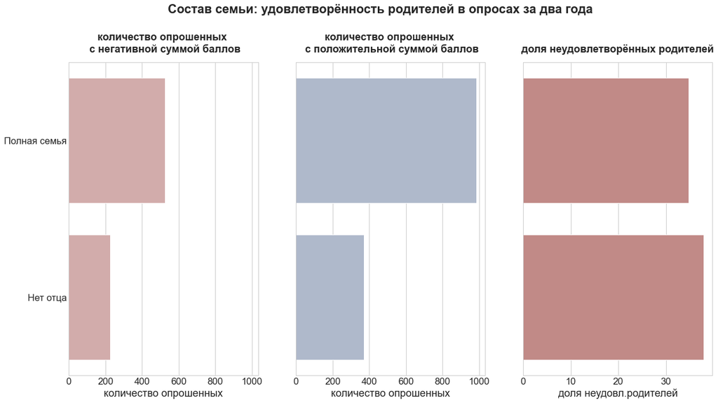

```python
plt.figure(figsize=(20, 10))
sns.set(font_scale=1.5)
plt.style.use('seaborn-whitegrid')
plt.suptitle('Состав семьи: удовлетворённость родителей в опросах за два года',
             fontweight='bold', y=1.02)

ax1=plt.subplot(1, 3, 1)
sns.barplot(data=type_family, y='is_family_full', x='status_neg', color='#d9a6a4')
plt.title('количество опрошенных \n с негативной суммой баллов', fontweight='bold', y=1.02)
plt.xlabel('количество опрошенных')
plt.ylabel('')

ax2=plt.subplot(1, 3, 2, sharex=ax1)
sns.barplot(data=type_family, y='is_family_full', x='status_pos', color='#aab8d0')
plt.title('количество опрошенных \n с положительной суммой баллов', fontweight='bold', y=1.02)
plt.xlabel('количество опрошенных')
plt.ylabel('')
ax2.set(yticklabels=[])
ax2.tick_params(left=False)

ax3=plt.subplot(1, 3, 3)
sns.barplot(data=type_family, y='is_family_full', x='perc', color='#ca817e')
plt.title('доля неудовлетворённых родителей', fontweight='bold', y=1.02)
plt.xlabel('доля неудовл.родителей')
plt.ylabel('')
ax3.set(yticklabels=[])
ax3.tick_params(left=False)

plt.show();
```

- большинство семей- полные
- доля неудовлетворённых родителей выше среди неполных семей - около 38%

### Тип заболевания ребёнка

```python
social_portreit_neg = (social_portreit.query('status == "negative"')
                                       .groupby('type_disease', as_index=False)
                                       .agg({'status':'count'})
                                       .rename(columns={'status':'status_neg'}))
social_portreit_pos = (social_portreit.query('status == "positive"')
                                       .groupby('type_disease', as_index=False)
                                       .agg({'status':'count'})
                                       .rename(columns={'status':'status_pos'}))
type_disease = social_portreit_neg.merge(social_portreit_pos, on='type_disease', how='outer')
type_disease = type_disease.sort_values(by='status_neg', ascending=False)
type_disease['cnt_total'] = type_disease['status_neg'] + type_disease['status_pos']
type_disease['perc'] = type_disease['status_neg'] / type_disease['cnt_total'] *100
type_disease = type_disease.sort_values(by='status_neg', ascending=False)
```

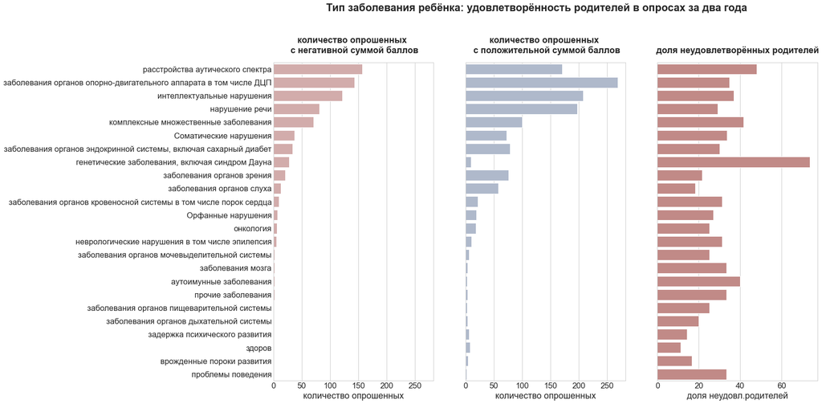

```python
plt.figure(figsize=(20, 12))
sns.set(font_scale=1.5)
plt.style.use('seaborn-whitegrid')
plt.suptitle('Тип заболевания ребёнка: удовлетворённость родителей в опросах за два года',
             fontweight='bold', y=1.02)

ax1=plt.subplot(1, 3, 1)
sns.barplot(data=type_disease, y='type_disease', x='status_neg', color='#d9a6a4')
plt.title('количество опрошенных \n с негативной суммой баллов', fontweight='bold', y=1.02)
plt.xlabel('количество опрошенных')
plt.ylabel('')

ax2=plt.subplot(1, 3, 2, sharex=ax1)
sns.barplot(data=type_disease, y='type_disease', x='status_pos', color='#aab8d0')
plt.title('количество опрошенных \n с положительной суммой баллов', fontweight='bold', y=1.02)
plt.xlabel('количество опрошенных')
plt.ylabel('')
ax2.set(yticklabels=[])
ax2.tick_params(left=False)

ax3=plt.subplot(1, 3, 3)
sns.barplot(data=type_disease, y='type_disease', x='perc', color='#ca817e')
plt.title('доля неудовлетворённых родителей', fontweight='bold', y=1.02)
plt.xlabel('доля неудовл.родителей')
plt.ylabel('')
ax3.set(yticklabels=[])
ax3.tick_params(left=False)

plt.show();
```

- наибольшее количество неудовлетворённых среди родителей детей с расстройствами аутического спектра, заболеваний органов опорно-двигательного аппарата в том числе ДЦП, интеллектуальными нарушениями
- наибольшая доля неудовлетворённых - среди родителей детей с генетическими заболеваниями, включая синдром Дауна - более 70%

### Размер семейного дохода

```python
social_portreit_neg = (social_portreit.query('status == "negative"')
                                       .groupby('amount_income', as_index=False)
                                       .agg({'status':'count'})
                                       .rename(columns={'status':'status_neg'}))
social_portreit_pos = (social_portreit.query('status == "positive"')
                                       .groupby('amount_income', as_index=False)
                                       .agg({'status':'count'})
                                       .rename(columns={'status':'status_pos'}))
type_amount_income = social_portreit_neg.merge(social_portreit_pos, on='amount_income', how='outer')
type_amount_income = type_amount_income.sort_values(by='status_neg', ascending=False)
type_amount_income['cnt_total'] = type_amount_income['status_neg'] + type_amount_income['status_pos']
type_amount_income['perc'] = type_amount_income['status_neg'] / type_amount_income['cnt_total'] *100
type_amount_income = type_amount_income.sort_values(by='status_neg', ascending=False)
type_amount_income
```

|  | amount_income | status_neg | status_pos | cnt_total | perc |
| --- | --- | --- | --- | --- | --- |
| 1 | Семье с трудом хватает средств на необходимые траты, связанные с питанием, одеждой, оплатой счетов и лечения | 225 | 274 | 499 | 45.090180 |
| 2 | Семье хватает средств на необходимые траты, но на большие покупки и отдых приходится копить (брать кредит) | 207 | 459 | 666 | 31.081081 |
| 3 | Семье хватает средств на необходимые траты, связанные с питанием, одеждой, оплатой счетов и лечения | 189 | 407 | 596 | 31.711409 |
| 0 | Семье не хватает средств на необходимые траты, связанные с питанием, одеждой, оплатой счетов и лечения | 105 | 93 | 198 | 53.030303 |
| 4 | Семье хватает средств не только на необходимые траты, но и на большие покупки, комфортный отдых | 25 | 124 | 149 | 16.778523 |

```python
def short_title(amount_income):
    for title in amount_income:
        result=textwrap.shorten(amount_income, width=60, placeholder='...')
        return result
```

```python
type_amount_income.insert(1, 'short_amount_income', type_amount_income['amount_income'].apply(short_title))
```

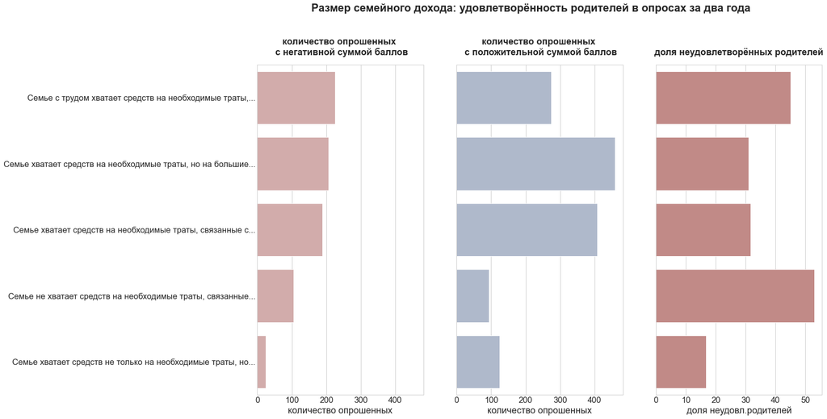

```python
plt.figure(figsize=(20, 12))
sns.set(font_scale=1.5)
plt.style.use('seaborn-whitegrid')
plt.suptitle('Размер семейного дохода: удовлетворённость родителей в опросах за два года',
             fontweight='bold', y=1.02)

ax1=plt.subplot(1, 3, 1)
sns.barplot(data=type_amount_income, y='short_amount_income', x='status_neg', color='#d9a6a4')
plt.title('количество опрошенных \n с негативной суммой баллов', fontweight='bold', y=1.02)
plt.xlabel('количество опрошенных')
plt.ylabel('')

ax2=plt.subplot(1, 3, 2, sharex=ax1)
sns.barplot(data=type_amount_income, y='short_amount_income', x='status_pos', color='#aab8d0')
plt.title('количество опрошенных \n с положительной суммой баллов', fontweight='bold', y=1.02)
plt.xlabel('количество опрошенных')
plt.ylabel('')
ax2.set(yticklabels=[])
ax2.tick_params(left=False)

ax3=plt.subplot(1, 3, 3)
sns.barplot(data=type_amount_income, y='short_amount_income', x='perc', color='#ca817e')
plt.title('доля неудовлетворённых родителей', fontweight='bold', y=1.02)
plt.xlabel('доля неудовл.родителей')
plt.ylabel('')
ax3.set(yticklabels=[])
ax3.tick_params(left=False)

plt.show();
```

- среди неудовлетворённых много семей, которым с трудом хватает средств на необходимые траты
- наибольшая доля неудовлетворённых среди семей, которым не хватает средств на необходимые траты - 53% и с трудом хватает средств на необходимые траты - 45%

### Уровень жизни семьи

```python
social_portreit_neg = (social_portreit.query('status == "negative"')
                                       .groupby('financial_level', as_index=False)
                                       .agg({'status':'count'})
                                       .rename(columns={'status':'status_neg'}))
social_portreit_pos = (social_portreit.query('status == "positive"')
                                       .groupby('financial_level', as_index=False)
                                       .agg({'status':'count'})
                                       .rename(columns={'status':'status_pos'}))
type_financial_level = social_portreit_neg.merge(social_portreit_pos, on='financial_level', how='outer')
type_financial_level = type_financial_level.sort_values(by='status_neg', ascending=False)
type_financial_level['cnt_total'] = type_financial_level['status_neg'] + type_financial_level['status_pos']
type_financial_level['perc'] = type_financial_level['status_neg'] / type_financial_level['cnt_total'] *100
type_financial_level = type_financial_level.sort_values(by='status_neg', ascending=False)
```

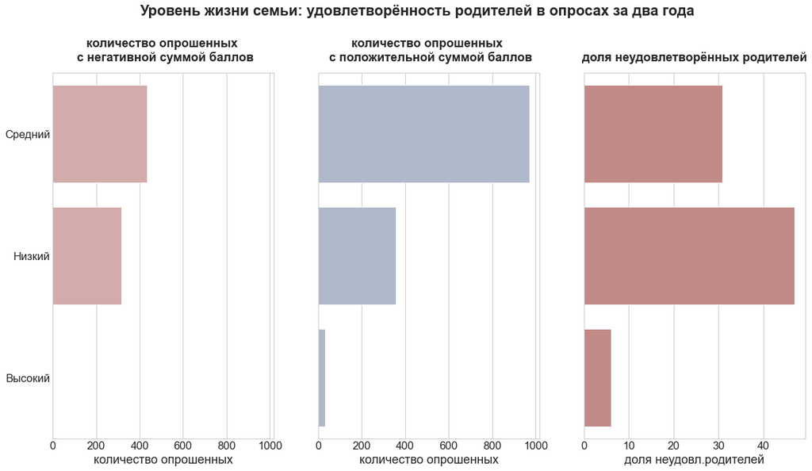

```python
plt.figure(figsize=(20, 10))
sns.set(font_scale=1.5)
plt.style.use('seaborn-whitegrid')
plt.suptitle('Уровень жизни семьи: удовлетворённость родителей в опросах за два года',
             fontweight='bold', y=1.02)

ax1=plt.subplot(1, 3, 1)
sns.barplot(data=type_financial_level, y='financial_level', x='status_neg', color='#d9a6a4')
plt.title('количество опрошенных \n с негативной суммой баллов', fontweight='bold', y=1.02)
plt.xlabel('количество опрошенных')
plt.ylabel('')

ax2=plt.subplot(1, 3, 2, sharex=ax1)
sns.barplot(data=type_financial_level, y='financial_level', x='status_pos', color='#aab8d0')
plt.title('количество опрошенных \n с положительной суммой баллов', fontweight='bold', y=1.02)
plt.xlabel('количество опрошенных')
plt.ylabel('')
ax2.set(yticklabels=[])
ax2.tick_params(left=False)

ax3=plt.subplot(1, 3, 3)
sns.barplot(data=type_financial_level, y='financial_level', x='perc', color='#ca817e')
plt.title('доля неудовлетворённых родителей', fontweight='bold', y=1.02)
plt.xlabel('доля неудовл.родителей')
plt.ylabel('')
ax3.set(yticklabels=[])
ax3.tick_params(left=False)

plt.show();
```

- среди неудовлетворённых - семьи со средним и низким доходом
- наибольшая доля неудовлетворённых среди семей с низким уровнем дохода - 48%

### Какой процент уходит на содержание ребёнка

```python
social_portreit_neg = (social_portreit.query('status == "negative"')
                                       .groupby('perc_costs_child', as_index=False)
                                       .agg({'status':'count'})
                                       .rename(columns={'status':'status_neg'}))
social_portreit_pos = (social_portreit.query('status == "positive"')
                                       .groupby('perc_costs_child', as_index=False)
                                       .agg({'status':'count'})
                                       .rename(columns={'status':'status_pos'}))
type_perc_costs_child = social_portreit_neg.merge(social_portreit_pos, on='perc_costs_child', how='outer')
type_perc_costs_child = type_perc_costs_child.sort_values(by='status_neg', ascending=False)
type_perc_costs_child['cnt_total'] = type_perc_costs_child['status_neg'] + type_perc_costs_child['status_pos']
type_perc_costs_child['perc'] = type_perc_costs_child['status_neg'] / type_perc_costs_child['cnt_total'] *100
type_perc_costs_child = type_perc_costs_child.sort_values(by='status_neg', ascending=False)
```

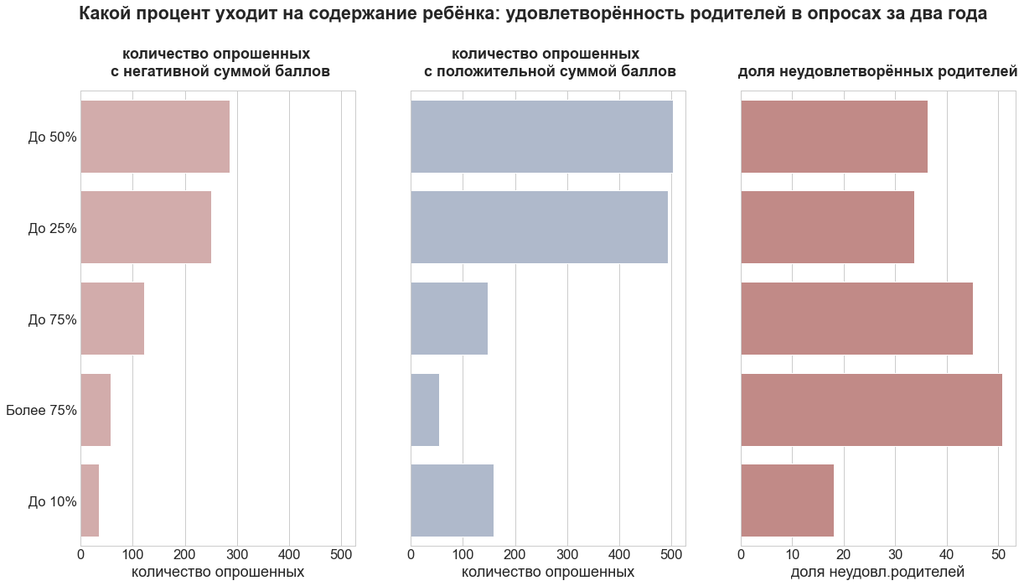

```python
plt.figure(figsize=(20, 10))
sns.set(font_scale=1.5)
plt.style.use('seaborn-whitegrid')
plt.suptitle('Какой процент уходит на содержание ребёнка: удовлетворённость родителей в опросах за два года',
             fontweight='bold', y=1.02)

ax1=plt.subplot(1, 3, 1)
sns.barplot(data=type_perc_costs_child, y='perc_costs_child', x='status_neg', color='#d9a6a4')
plt.title('количество опрошенных \n с негативной суммой баллов', fontweight='bold', y=1.02)
plt.xlabel('количество опрошенных')
plt.ylabel('')

ax2=plt.subplot(1, 3, 2, sharex=ax1)
sns.barplot(data=type_perc_costs_child, y='perc_costs_child', x='status_pos', color='#aab8d0')
plt.title('количество опрошенных \n с положительной суммой баллов', fontweight='bold', y=1.02)
plt.xlabel('количество опрошенных')
plt.ylabel('')
ax2.set(yticklabels=[])
ax2.tick_params(left=False)

ax3=plt.subplot(1, 3, 3)
sns.barplot(data=type_perc_costs_child, y='perc_costs_child', x='perc', color='#ca817e')
plt.title('доля неудовлетворённых родителей', fontweight='bold', y=1.02)
plt.xlabel('доля неудовл.родителей')
plt.ylabel('')
ax3.set(yticklabels=[])
ax3.tick_params(left=False)

plt.show();
```

- среди неудовлетворённых большинство - семьи,которые тратят до 50% и 25% своего дохода на содержание ребёнка
- наибольшая доля неудовлетворённых среди семей, которые тратят до и более 75% дохода - это 45% и 51%